# ECO 602 - Analysis of Environmental Data

## `mean()`

The *mean()* function calculates the arithmetic mean of a numeric input vector.

- A basic application can be applied to vectors, shown here:

```r
vector_2 <- c(1:100) # Creates a vector of numbers.
mean(vector_2) # Apply mean function
```

```
## [1] 50.5
```

- The next example shows how to derive a mean value in a vector that has some null values, since letters cannot be computed arithmetically.

```r
vector_3 <- c(1, 5, 8, 3, NA, 0, 9, 78, 10, -2, -16) # Creates a vector of numbers with an NA value.
mean(vector_3) # Applies mean function - result is an error.
```

```
## [1] NA
```

```r
mean(vector_3, na.rm = TRUE) # Tells r to remove the NA values before computing the mean. The results show the correct numerical value.
```

```
## [1] 9.6
```

- The following examples applies the mean function to a real data set. We will use the *palmerpenguins* data set again.

```r
head(penguin_dat) # Prints head rows of the data set.
```

```
## # A tibble: 6 x 8
##   species island bill_length_mm bill_depth_mm flipper_length_~ body_mass_g sex
##   <fct>   <fct>           <dbl>         <dbl>            <int>       <int> <fct>
## 1 Adelie  Torge~           39.1          18.7              181        3750 male
## 2 Adelie  Torge~           39.5          17.4              186        3800 fema~
## 3 Adelie  Torge~           40.3          18                195        3250 fema~
## 4 Adelie  Torge~           NA            NA                 NA          NA <NA>
## 5 Adelie  Torge~           36.7          19.3              193        3450 fema~
## 6 Adelie  Torge~           39.3          20.6              190        3650 male
## # ... with 1 more variable: year <int>
```

```r
mean(penguins$bill_length_mm) # Calculates the mean of the bill length column. Results show 'NA' due to some NA values.
```

```
## [1] NA
```

```r
mean(penguins$bill_length_mm, na.rm = TRUE) # Tells r to remove NA values before calculating mean. Results show the desired numerical values.
```

```
## [1] 43.92193
```

## `sd()`

The *sd()* function calculates the standard deviation (sd) of a numeric input vector. This is the square root of data variance.

- One example of calculating the standard deviation for a vector is shown below. We will use a vector that we made earlier:

```r
vector_2     #Prints vector.
```

```
##   [1]   1   2   3   4   5   6   7   8   9  10  11  12  13  14  15  16  17  18
##  [19]  19  20  21  22  23  24  25  26  27  28  29  30  31  32  33  34  35  36
##  [37]  37  38  39  40  41  42  43  44  45  46  47  48  49  50  51  52  53  54
##  [55]  55  56  57  58  59  60  61  62  63  64  65  66  67  68  69  70  71  72
##  [73]  73  74  75  76  77  78  79  80  81  82  83  84  85  86  87  88  89  90
##  [91]  91  92  93  94  95  96  97  98  99 100
```

```r
sd(vector_2) # Applies the standard deviation calculation to the vector.
```

```
## [1] 29.01149
```

- The next example shows how to calculate the standard deviation for a vector with NA or NULL values. Again, we will use one of the vectors we created earlier with an NA value:

```r
vector_3               #Prints the vector.
```

```
##  [1]   1   5   8   3  NA   0   9  78  10  -2 -16
```

```r
sd(vector_3) # Applies the standard deviation (sd) calculation to the vector. Results show 'NA' due it containing NA values.
```

```
## [1] NA
```

```r
sd(vector_3, na.rm = TRUE) # Exactly like the previous functions, "na.rm" can be used to tell r to remove the NA value before calculating the mean. Results show the desired numerical values.
```

```
## [1] 25.17141
```

- Our Next example shows how to calculate the standard deviation for a data set. We will use the *palmerpenguins* data set again to visualize this.

```r
head(penguin_dat)              # Prints the head rows of the data set.
```

```
## # A tibble: 6 x 8
##   species island bill_length_mm bill_depth_mm flipper_length_~ body_mass_g sex
##   <fct>   <fct>           <dbl>         <dbl>            <int>       <int> <fct>
## 1 Adelie  Torge~           39.1          18.7              181        3750 male
## 2 Adelie  Torge~           39.5          17.4              186        3800 fema~
## 3 Adelie  Torge~           40.3          18                195        3250 fema~
## 4 Adelie  Torge~           NA            NA                 NA          NA <NA>
## 5 Adelie  Torge~           36.7          19.3              193        3450 fema~
## 6 Adelie  Torge~           39.3          20.6              190        3650 male
## # ... with 1 more variable: year <int>
```

```r
sd(penguin_dat$bill_length_mm) # Applies the standard deviation to a specified variable using the "$". Again, there is an NA value in this variable.
```

```
## [1] NA
```

```r
sd(penguin_dat$bill_length_mm, na.rm = TRUE) # Tell r not to calculate NA values. Results show numerical values.
```

```
## [1] 5.477062
```

# Functions 3: Graphical Data Exploration

One of the biggest use cases for using R is due to its graphic capabilities. In R, there are many ways of creating graphical representations of your data. Some common examples are histograms, boxplots, and scatterplots.

## ‘par()’

The *‘par()’ function takes multiple graphs and combines them into a single graphical representation.

- The function ‘mfrow=c(nrows, ncols)’ creates a matrix of ‘nrows’ (number of rows) by ‘ncols’ (number of columns) plots that are populated by row. Using the ‘mfcol=c(nrows, ncols)’ function populates the matrix by column.
- An example of how to use the *‘par()’* function with the *mfrow=c(2,2)’* function is shown here:

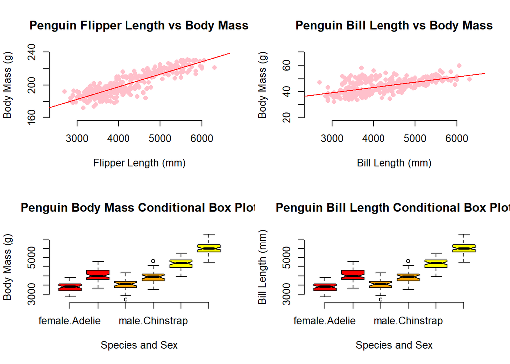

```r
attach(penguins) # Species which data set to use.
par(mfrow=c(2,2)) # Specifies 2 rows and 2 columns.

plot(
  flipper_length_mm ~ body_mass_g,
  data = penguins,
  main = "Penguin Flipper Length vs Body Mass",
  xlab = "Flipper Length (mm)",
  ylab = "Body Mass (g)",
  col = "pink",
  pch = 16,
  frame = FALSE,
  xlim = c(2500,6500),
  ylim = c(160,240))

abline(lm(flipper_length_mm~body_mass_g, data=penguins), col="red")

plot(
  bill_length_mm ~ body_mass_g,
  data = penguins,
  main = "Penguin Bill Length vs Body Mass",
  xlab = "Bill Length (mm)",
  ylab = "Body Mass (g)",
  col = "pink",
  pch = 16,
  frame = FALSE,
  xlim = c(2500,6500),
  ylim = c(20,70))

abline(lm(bill_length_mm~body_mass_g, data=penguins), col="red")

boxplot(body_mass_g ~ sex * species,
        data = penguins,
        main = "Penguin Body Mass Conditional Box Plot",
        xlab = "Species and Sex",
        ylab = "Body Mass (g)",
        frame = FALSE,
        notch = TRUE,
        col = (c("red", "red", "orange", "orange", "yellow", "yellow")))

boxplot(body_mass_g ~ sex * species,
        data = penguins,
        main = "Penguin Bill Length Conditional Box Plot",
        xlab = "Species and Sex",
        ylab = "Bill Length (mm)",
        frame = FALSE,
        notch = TRUE,
        col = (c("red", "red", "orange", "orange", "yellow", "yellow")))
```

## ‘plot()’

The *‘plot()’* function is used to create scatter plots of your data.

- Our first example will show how to create a scatterplot using the *palmerpenguins* data.

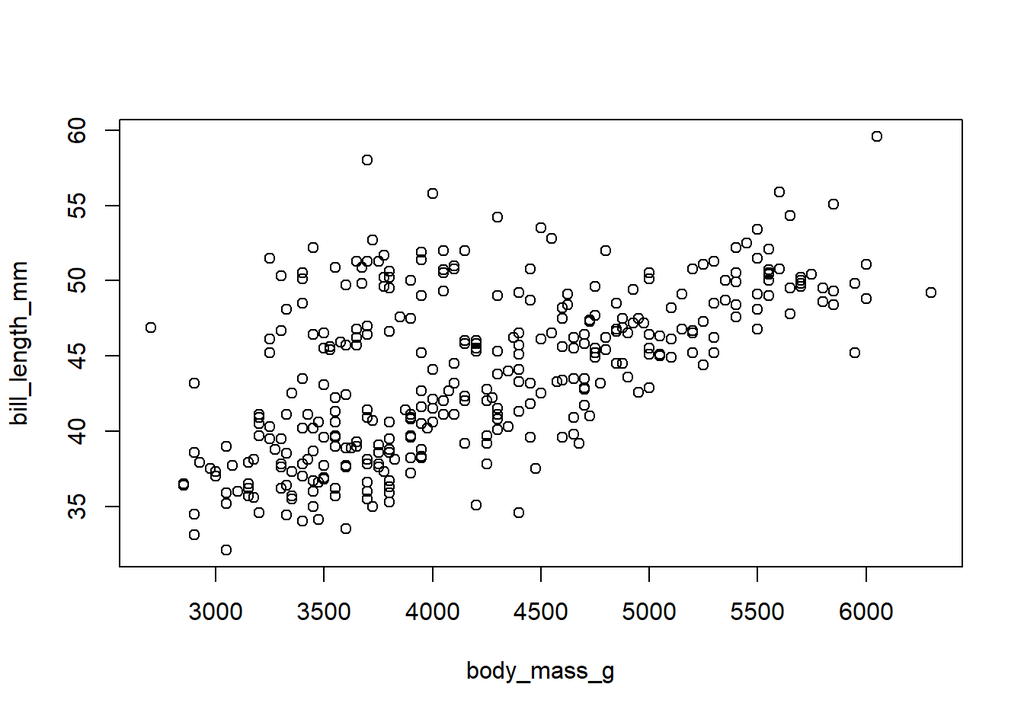

```r
require(palmerpenguins) # Loads in the penguins package
plot(bill_length_mm ~ body_mass_g, # First variable specifies x direction, Second variable specifies y direction of graph.
     data = penguins)# Specifies data set.
```

- The next example will show how to create a more in depth scatterplot, using the same *palmerpenguins* data. In addition, the following example will adjust the x and y limits of the graph.

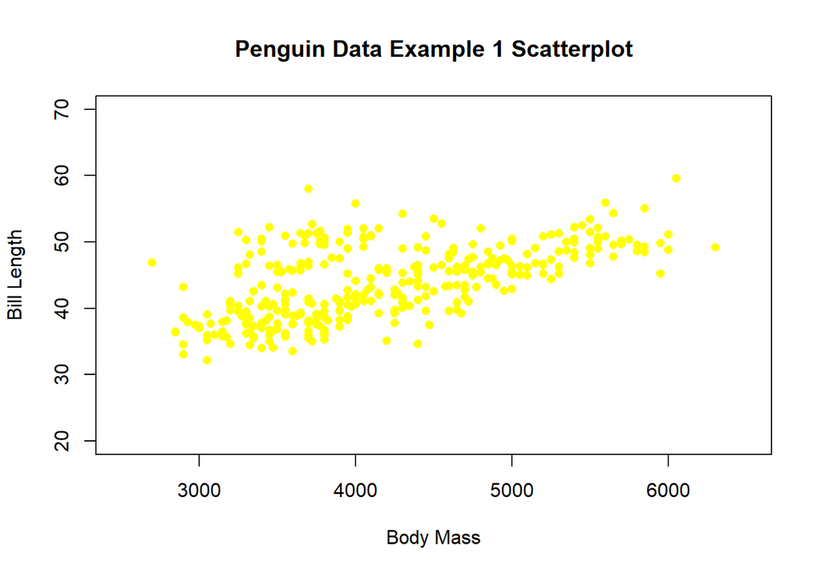

```r
plot(
  bill_length_mm ~ body_mass_g, # First variable (x direction), Second variable (y direction) of the graph.
  data = penguins, # Specifies the data.
  main = "Penguin Data Example 1 Scatterplot", #Adds a title.
  xlab = "Body Mass", # Names the x coordinate.
  ylab = "Bill Length", # Names the y coordinate,
  col = "yellow", # Defines the color
  pch = 16, #pch numbers represent different graphical symbols
  xlim = c(2500,6500), # Adjusts the x coordinate limit
  ylim = c(20,70)) # # Adjusts the y coordinate limit
```

## ‘hist()’

The *‘hist()’* function is used to create histograms data. Histograms are great choice when analyzing general distribution of a variable(s).

- The first example below shows how to create a simple histogram, and uses the *palmerpenguins* data again:
  - Histograms show specific variables (assigned by you) in the x axis and frequency (occurrence) in the y.
  - If frequency is set as FALSE, the y axis shows density.

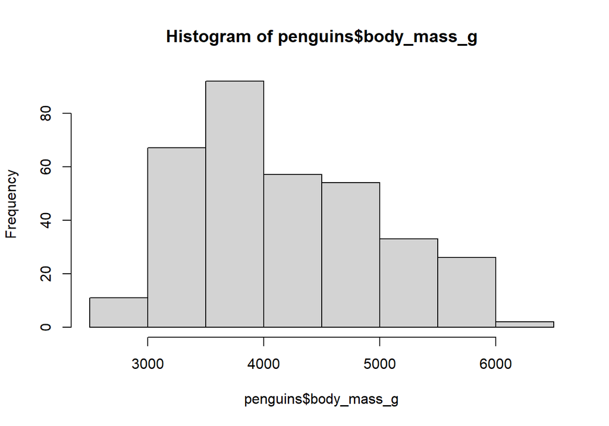

```r
hist(penguins$body_mass_g) # Specifies data set and one variable to graph.
```

- The second example shows how to create a more complex histogram of a data set:

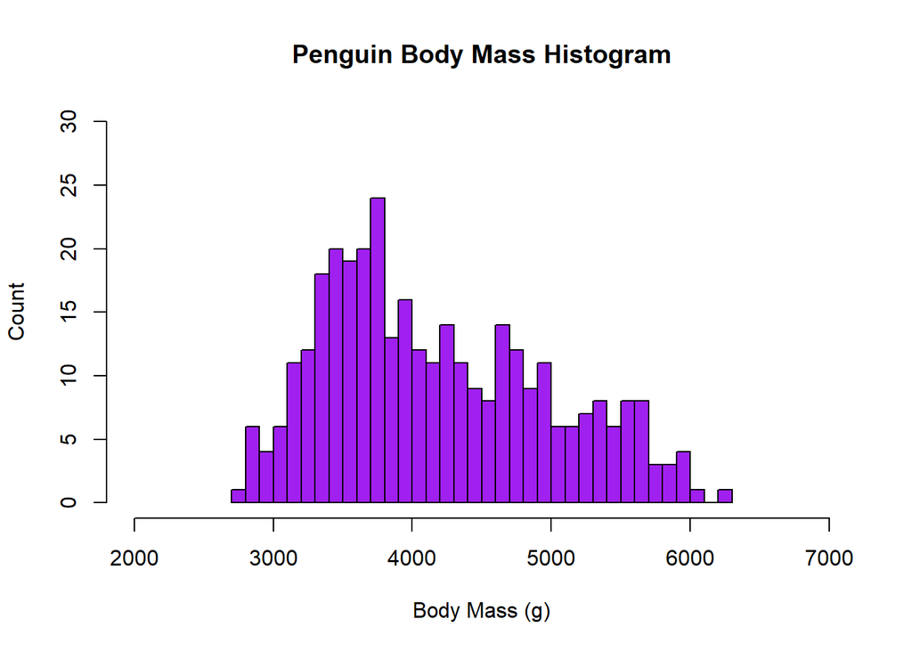

```r
hist(penguins$body_mass_g,
     breaks = 50, # Designates the number of breaks (bins) between bars along the x axis. This, in many cases reveals more detailed variation in the numerical values and trend of the graph.
     main = "Penguin Body Mass Histogram", # Title
     xlab = "Body Mass (g)",# Names the x axis.
     ylab = "Count", # Names the y axis.
     col = "purple", # Specifies color.
     xlim = c(2000,7000), # Adjusts the x coordinate limit
     ylim = c(0, 30)) # Adjusts the y coordinate limit
```

- Histograms can also be used to develop density plots, which is a curve that represents the variations in the data.

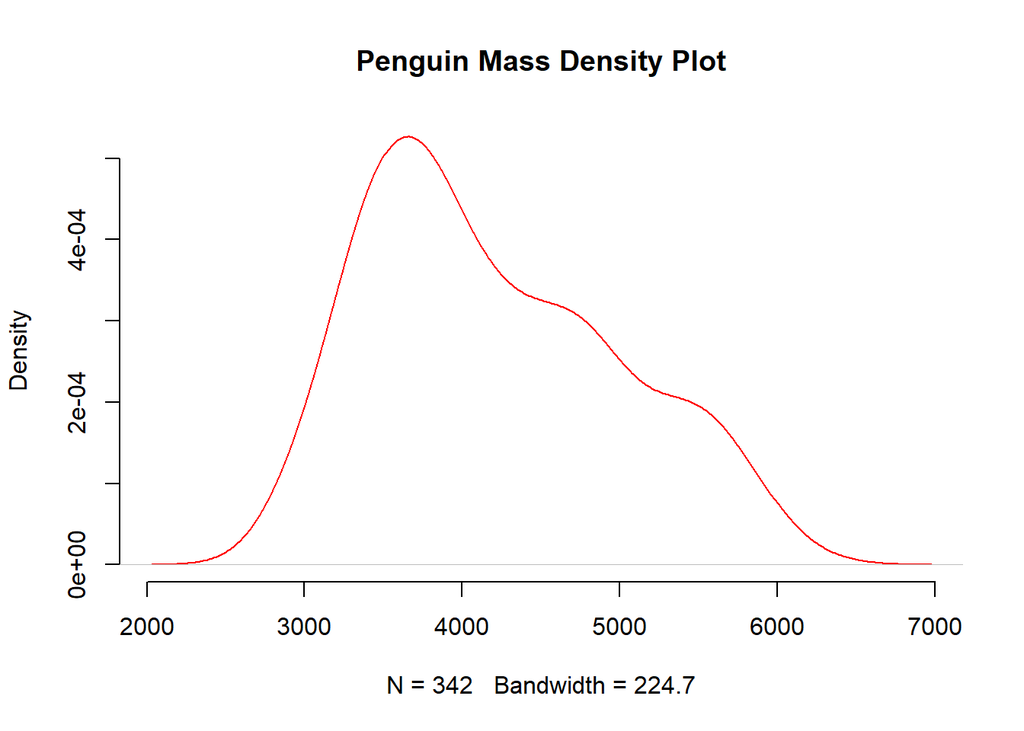

```r
plot(density
     (penguins$body_mass_g, # Specifies data, and one variable to graph.
       na.rm = TRUE), #Tells R to remove the NA value before calculating curve.
     main = "Penguin Mass Density Plot", #Names the graph
     col = "red", #Specifies color
     frame = FALSE) #Specifies no box frame
```

## ‘boxplot()’

The *‘box()’* function is used to create box plot diagrams of the data. Boxplots are a type of graphical mapping that shows data distribution, its central value indicated by the black bar, and also its variability shown as the lowermost and uppermost boundaries of the box. Boxplots can also compare multiple sets of data in a single representation, which is why they are very useful in making comparisons.

- The first box plot example shows a simple, single variable analysis. Again, using the *palmerpenguins* data, this graphs penguin body mass conditioned on species.

```r
summary(penguins) # Prints summary of data set.
```

```
##       species          island    bill_length_mm  bill_depth_mm
##  Adelie   :152   Biscoe   :168   Min.   :32.10   Min.   :13.10
##  Chinstrap: 68   Dream    :124   1st Qu.:39.23   1st Qu.:15.60
##  Gentoo   :124   Torgersen: 52   Median :44.45   Median :17.30
##                                  Mean   :43.92   Mean   :17.15
##                                  3rd Qu.:48.50   3rd Qu.:18.70
##                                  Max.   :59.60   Max.   :21.50
##                                  NA's   :2       NA's   :2
##  flipper_length_mm  body_mass_g       sex           year
##  Min.   :172.0     Min.   :2700   female:165   Min.   :2007
##  1st Qu.:190.0     1st Qu.:3550   male  :168   1st Qu.:2007
##  Median :197.0     Median :4050   NA's  : 11   Median :2008
##  Mean   :200.9     Mean   :4202                Mean   :2008
##  3rd Qu.:213.0     3rd Qu.:4750                3rd Qu.:2009
##  Max.   :231.0     Max.   :6300                Max.   :2009
##  NA's   :2         NA's   :2
```

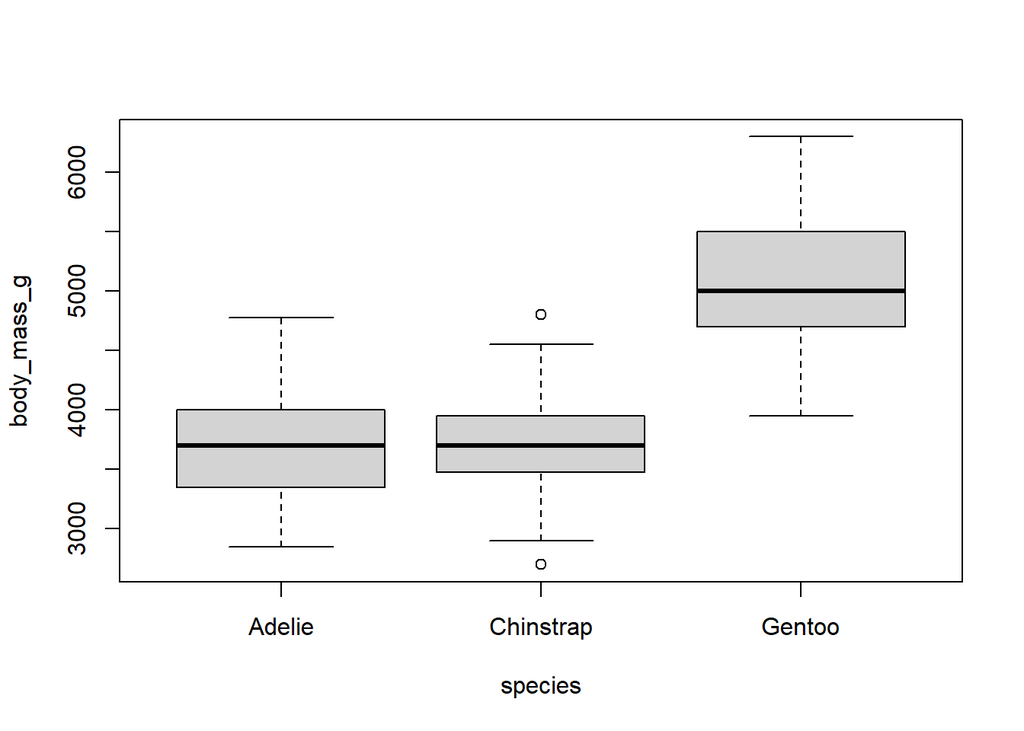

```r
boxplot(body_mass_g~species, # Specifies two variables.
        data = penguins) # Specify data set.
```

- The second example is of a *conditional* box plot, which shows several variables that you can then compare. Again, using the *palmerpenguins* data set, we will graph penguin body mass conditioned on both species and sex.

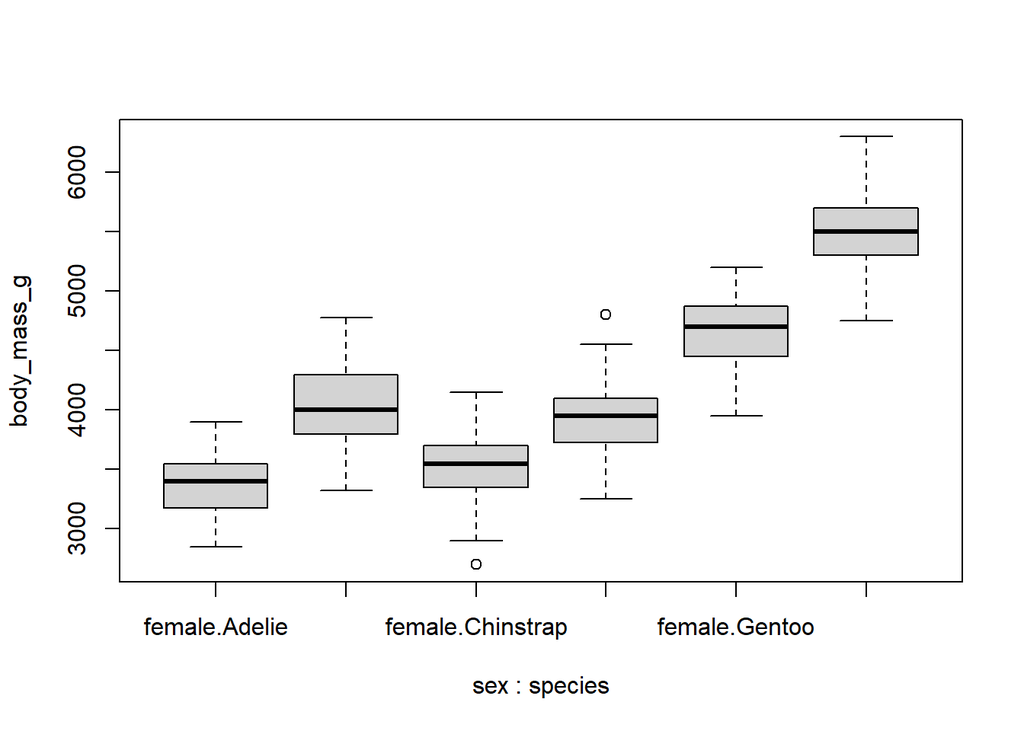

```r
boxplot(body_mass_g ~ sex * species, # Specifies three variables.
        data = penguins) # Specifies data set.
```

- Here is one last example which can be used with box plots to enhance the representation of data:

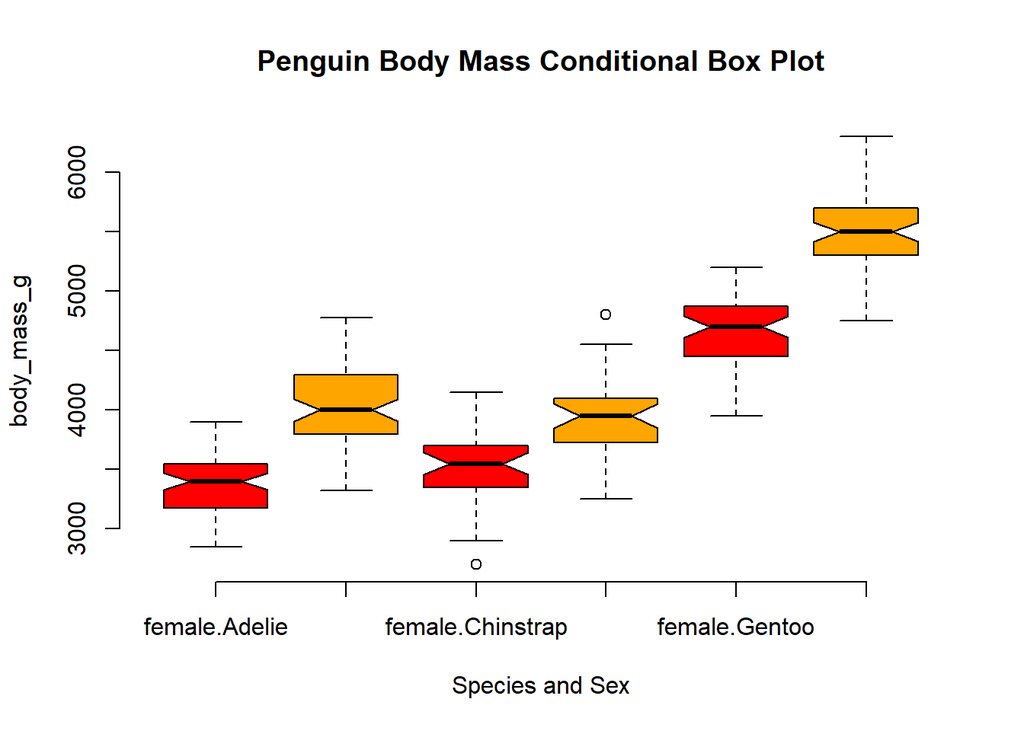

```r
boxplot(body_mass_g ~ sex * species, # Specifies three variables.
        data = penguins, # Specifies data set.
        main = "Penguin Body Mass Conditional Box Plot", # Names the box plot
        xlab = "Species and Sex", # Conditional variables.
        frame = FALSE, # Specifies no box frame of graph, otherwise TRUE as default
        notch = TRUE, # Specifies notch, otherwise FALSE as default; helps visualize the mean.
        col = (c("red", "orange"))) # Specifies colors.
```

# Functions 4: Distribution Functions

The following section demonstrates some of the most common probability distribution functions which describe the likelihood of obtaining the possible values that a random variable can assume. These equations are split into two categories, normal distribution functions and binomial distribution functions.

The main difference between normal and binomial distribution functions is that they answer two different questions. Normal distribution functions calculate the probability of a *single trial outcome*, in contrast binomial distribution functions calculate probability for *one or multiple trials* to answer the same questions, where each trial is run independently.

The two types of questions these functions answer are defined as the *“d”*, *“p”* and *“q”* prefix in the scripts.

- For a normal distribution, the functions are defined as: *dnorm*, *pnorm* and *qnorm*.
- For a binomial distribution, the functions are defined as: *dbinom*, *pbinom* and *qbinom*.
- These three different commands for each distribution type indicate the following functions:
  - *“d”* returns the height of the probability density function
  - *“p”* returns the cumulative density function
  - *“q”* returns the inverse cumulative density function (quantiles)
- Normal distribution functions have two parameters: *µ* (mean) and *σ* (sd or standard deviance)
  - The Standard Normal distribution has µ = 0 and σ = 1
  - The mean moves the curve to the left or right.
  - The standard deviation σ controls the width and flatness.
- Binomial distribution functions work similarly to the normal distribution commands. However, they have two additional parameters: *n* (number of trials, referred to as *“size”*) and *p* (probability of the success of a single trial, referred to as *“prob”* in the script). For the number of trials, the value must be an integer in order for these functions work correctly.

## ‘dnorm()’

*dnorm(x, mean, sd)*

The *‘dnorm()’* function returns the height of the probability distribution for each point in the data set, given the three parameters x (or independent variable), mean, and sd (standard deviation). The *“d”* in dnorm stands for *“density.”* Thus, the command dnorm is designed to provide values of the probability density function for the normal distribution.

- Mean = 0 and sd = 1 are the default arguments for the *‘dnorm()’* function, shown in the simple example below:

```r
dnorm(0) #x value is specified as zero, mean = 0 and sd = 1 by default.
```

```
## [1] 0.3989423
```

```r
dnorm(0, mean = 0, sd = 1) # This function can be written like this.
```

```
## [1] 0.3989423
```

```r
dnorm(0, 0, 1) # This function can also be written like this as well.
```

```
## [1] 0.3989423
```

- The next example will perform the *‘dnorm()’* function using a normally distributed vector of x variables to show a normal distribution function. This example assumes the mean = 0, and sd = 1

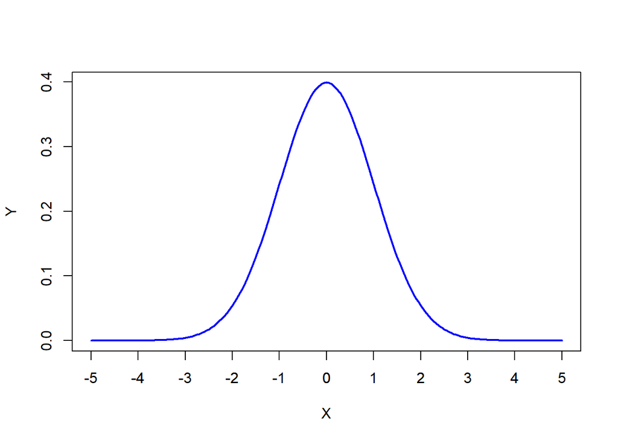

```r
x_dnorm <- seq(- 5, 5, by = 0.05) # Create a sequence of equally spaced numbers between specified values.
y_dnorm <- dnorm(x_dnorm) # Apply the dnorm function
plot(x_dnorm, y_dnorm, # Plot dnorm values
     type="l", # Specifies a line type graph, default is open circle points
     lwd=2, # Specifies line thickness
     col ="blue", # Specifies line color
     xlab = "X", # Specifies x-axis title
     ylab = "Y") # Specifies y-axis title
axis(1, at = -5:5) #Specify x-axis values
```

- The next example will perform the same *‘dnorm()’* function while altering the mean and sd values to show it’s impact on the graphed curve. A lower mean value shifts the curve (shifting the mean value) to the left. The higher sd value widens and flattens the curve.

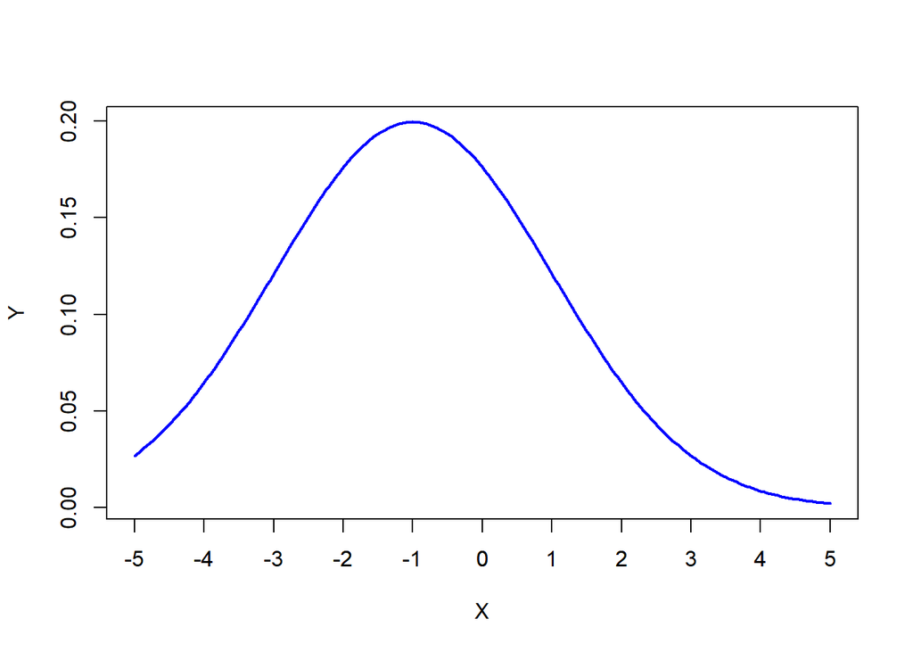

```r
x_dnorm <- seq(- 5, 5, by = 0.05)
y_dnorm <- dnorm(x_dnorm, mean = -1, sd = 2) # Apply the dnorm function, specify mean and sd values.
plot(x_dnorm, y_dnorm,
     type="l",
     lwd=2,
     col ="blue",
     xlab = "X",
     ylab = "Y")
axis(1, at = -5:5)
```

- This function is useful in deriving a likelihood probability for a specific value. An example that was learned in class referenced a fish population. This function was used to answer the question: *“Is catching a fish 6cm length more likely than catching a fish of 14.5cm length”?* Looking at a normal distribution graph, and locating the x value of both 6 and 14.5, the y-axis value can be derived which indicates that percentage probability. Results of this example indicated that for an x=6, the y (or the f(x)) was 0.04, while for an x=14.5, the y value was .07, which means that catching a length of 14.5 was more probable.

## ‘pnorm()’

*pnorm(q, mean, sd, lower.tail)*

The *‘pnorm()’* function computes the probability that a normally distributed random number will be less than that number. This function is also referred to as the *“Cumulative Distribution Function.”* It accepts the same options as dnorm, and calculates the probability as the cumulative area under the distribution curve. The total area under the curve is always equal to 1, or 100% probability. The *lower.tail* variable in the command is logical. When *TRUE* (which is the default), it implies the probability of less than or equal to x (or *q*), and when *FALSE*, it implies a probability of greater than or equal to x (or *q*).

- pnorm() differs from dnorm(), which calculates a definite y value for each exact value of x, the pnorm is used if we want to know the probability of all values of x that are less than a chosen value.
- Similarly to dnorm, the mean = 0 and sd = 1 which are the default arguments for the *‘pnorm()’* function, as depicted in the example below. The result will always be .5 in this example, as there is 50% probability of values being within the first half of the area underneath the normal distribution curve.

```r
pnorm(0) #x value is zero, mean = 0 and sd = 1 (defaults).
```

```
## [1] 0.5
```

```r
pnorm(0, mean = 0, sd = 1) # One way to write this function.
```

```
## [1] 0.5
```

```r
pnorm(0, 0, 1) # A different way of writing this function.
```

```
## [1] 0.5
```

- The next example will go through the *‘pnorm()’* function using a previously developed normal distribution curve. This example assumes the mean = 0, and sd = 1.

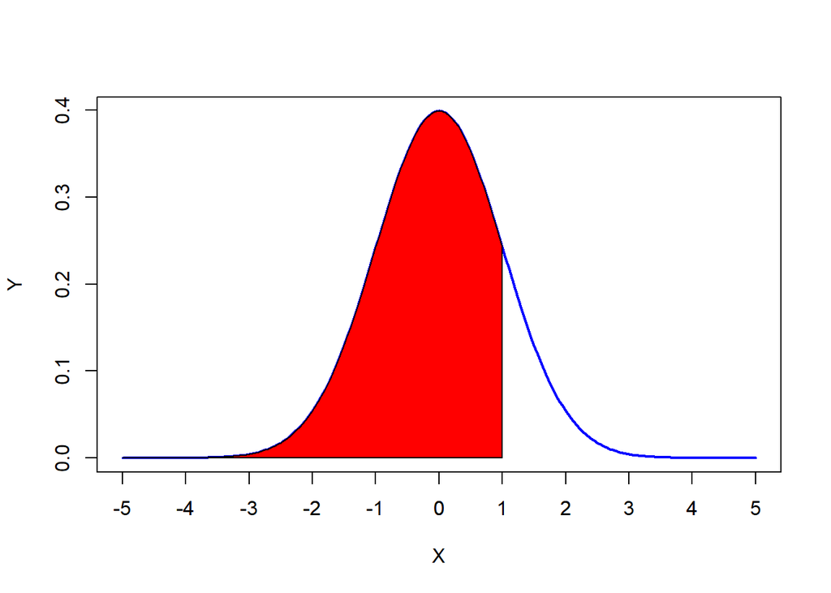

```r
x_dnorm <- seq(- 5, 5, by = 0.05) # Repeated normal distribution curve from previous example.
y_dnorm <- dnorm(x_dnorm)
plot(x_dnorm, y_dnorm,
     type="l",
     lwd=2,
     col ="blue",
     xlab = "X",
     ylab = "Y")
axis(1, at = -5:5)

x_pnorm <- seq(-5, 1, by = 0.05) # Creates a sequence of equally spaced numbers between specified values for the pnorm function. In this example we are looking at values of x < 1.
y_pnorm <- dnorm(x_pnorm) #Apply dnorm function
polygon(c(-5,x_pnorm, 1),c(0,y_pnorm,0),col="red") # Plots the dnorm function as an area under the curve. We selected the area of x < 1.
```

- To verify this illustrated concept:

```r
pnorm(1, 0, 1) # Verify this graphic example. Result is that the probability of x being less than 1 is 84%. Our graph looks correctly done as a visual representation of this concept.
```

```
## [1] 0.8413447
```

- This function is useful for deriving a likelihood probability between two values, or a range of values. An example that was learned in class referenced a fish population, and this function was used to answer a question such as: *“What is the probability of of catching a fish that weighs 153 grams of less”?* Looking at a normal distribution graph, locating the x value of 153, and calculating the area underneath the curve from that specified value to the left resulted in a value of 0.6 or 60%.
- An important nuance is that this function always calculates the entire area to the left of a specified x value. So, if we are looking for a range between two values, we would have to subtract the smaller area to the left of the specified range value from a larger area to the left of the second range value. See an example of this below:

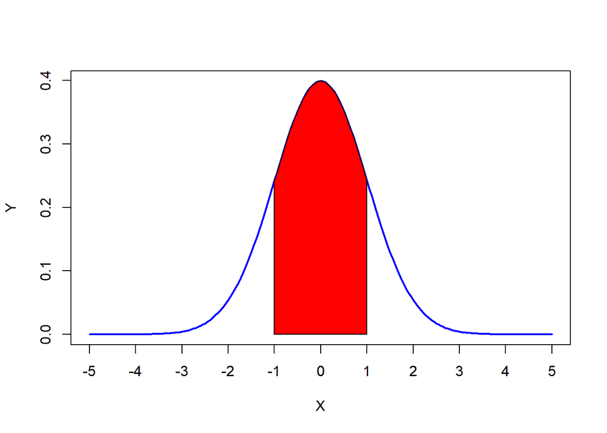

```r
x_dnorm <- seq(- 5, 5, by = 0.05) # Repeat the normal distribution curve from previous example first
y_dnorm <- dnorm(x_dnorm)
plot(x_dnorm, y_dnorm,
     type="l",
     lwd=2,
     col ="blue",
     xlab = "X",
     ylab = "Y")
axis(1, at = -5:5)

x_pnorm <- seq(-1, 1, by = 0.05)
y_pnorm <- dnorm(x_pnorm)
polygon(c(-1,x_pnorm, 1),c(0,y_pnorm,0),col="red") # Plot dnorm function as an area under the curve. We selected cumulative range area of -1 < x < 1.
```

- To verify this illustrated concept:

```r
pnorm(1, 0, 1) - pnorm (-1, 0, 1) # Verify this graphic example. Result is that the probability of a range of x being between values of -1 and 1 is 68%. Our graph looks correctly done as a visual representation of this concept.
```

```
## [1] 0.6826895
```

## ‘qnorm()’

*qnorm(p, mean, sd, lower.tail)*

The *‘qnorm()’* function computes the inverse of the pnorm function. The input is the desired percentile of probability and the output is the range of x values that meets that percentile. The *lower.tail* variable in the command is logical. When *TRUE* (which is default), it implies probability of less than or equal to x (or *p*), and when *FALSE*, it implies greater than or equal to x (or *p*).

- Similar to dnorm, and pnorm functions, Mean = 0 and sd = 1 are the default arguments for the *‘qnorm()’* function, as shown in the simple example below.

```r
qnorm(.9) #probability value is specified as 90%, mean = 0 and sd = 1 by default.
```

```
## [1] 1.281552
```

```r
qnorm(.9, mean = 0, sd = 1) # This function can be written like this.
```

```
## [1] 1.281552
```

```r
qnorm(.9, 0, 1) # This function can also be written like this as well.
```

```
## [1] 1.281552
```

- It must be emphasized that the area under the curve to the left is used when applying both commands *pnorm* and *qnorm*. If we are to solve for an area to the right of an x value, we must perform a similar subtraction process, where we subtract that percentage input from a value of 1, or 100%.
- This function is useful in deriving a range of values values, or a range of values. An example that was learned in class referenced a fish population, and this function was used to answer a question such as: *"What is the 90th percentile of fish lenghts?* or, in other words, *What lenght will 90% of the fish population be lower than?* Looking at a normal distribution graph, locating the x value at 90% of shaded area underneath the curve derived an x value of 13.28, meaning that 90% of the fish is 13.28 mm long or less.

## ‘dbinom()’

*dbinom(x, size, prob)*

Similar to normal distribution functions, the *‘dbinom()’* function shows the density. It helps to find the individual probabilities as well as a range of probabilities. It provides the probability of a number of successful trials (*x*), from a number of total trials (*size*), based on a probability of a positive result for each trial (*prob*).

```r
dbinom(10, 10, 0.2) # This function asks for 10 successful outcomes.
```

```
## [1] 1.024e-07
```

```r
dbinom(10, size = 10, prob = .2) # This is how you write this function.
```

```
## [1] 1.024e-07
```

```r
dbinom(10, 10, .2) # Here is another way to write this.
```

```
## [1] 1.024e-07
```

```r
dbinom(10, 10, .6) # Changing the probability for comparison
```

```
## [1] 0.006046618
```

```r
dbinom(10, 20, .2) # Changing the size, or number of trials, for comparison
```

```
## [1] 0.002031414
```

```r
dbinom(10, 20, .6) # Changing the size and probability for comparison
```

```
## [1] 0.1171416
```

```r
dbinom(0:10, 10, .2) #We can also ask for a range of 10 or less successful outcomes using this function. The second example below illustrates these ranges graphically.
```

```
##  [1] 0.1073741824 0.2684354560 0.3019898880 0.2013265920 0.0880803840
##  [6] 0.0264241152 0.0055050240 0.0007864320 0.0000737280 0.0000040960
## [11] 0.0000001024
```

- In the following example, we will plot these concepts into line graphs, for comparisons:

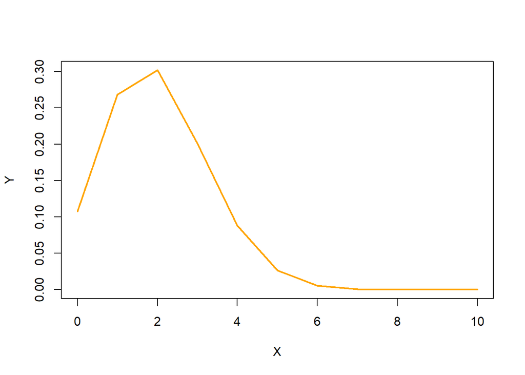

```r
x_dbinom <- seq(0, 10, by = 1) # Creates a sequence of equally spaced numbers between specified values.

y_dbinom <- dbinom(x_dbinom, size = 10, prob = .2) # Apply the dbinom function.
plot(x_dbinom, y_dbinom, # Plot dbinom values.
     type="l", # Specifies a line type graph (default is open circle points).
     lwd=2, # Defines the line thickness.
     col ="orange", # Defines line color.
     xlab = "X", # Defines x-axis title.
     ylab = "Y") # Specifies y-axis title.
```

```r
dbinom(0:10, 10, .2) #The resulting answers correspond with the y-axis probability for each x value in the range of 0 to 10.
```

```
##  [1] 0.1073741824 0.2684354560 0.3019898880 0.2013265920 0.0880803840
##  [6] 0.0264241152 0.0055050240 0.0007864320 0.0000737280 0.0000040960
## [11] 0.0000001024
```

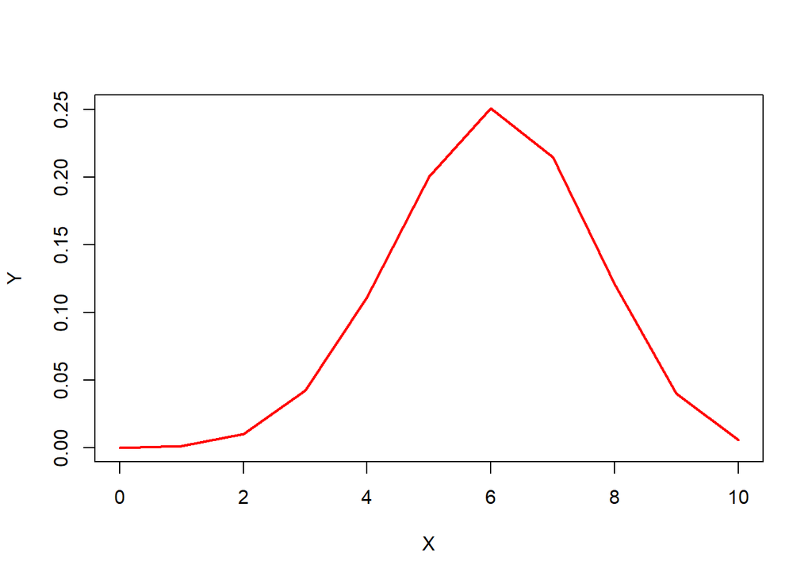

```r
y_dbinom <- dbinom(x_dbinom, size = 10, prob = .6) # Changing the probability to compare.
plot(x_dbinom, y_dbinom,
     type="l",
     lwd=2,
     col ="red",
     xlab = "X",
     ylab = "Y")
```

```r
dbinom(0:10, 10, .6) #The resulting answers correspond with the y-axis probability for each x value in the range from 0 to 10.
```

```
##  [1] 0.0001048576 0.0015728640 0.0106168320 0.0424673280 0.1114767360
##  [6] 0.2006581248 0.2508226560 0.2149908480 0.1209323520 0.0403107840
## [11] 0.0060466176
```